# Most harmful types of events across the United States

Javier Angoy

May 6th, 2017

## Synopsis

The basic goal of this assignment is to explore the NOAA Storm Database and answer two basic questions about severe weather events:  
1. Across the United States, which types of events (as indicated in the EVTYPE variable) are most harmful with respect to population health?  
2. Across the United States, which types of events have the greatest economic consequences?

## Data Processing

The data for this assignment come in the form of a comma-separated-value file compressed via the bzip2 algorithm to reduce its size, and can be downloaded from the site: “https://d396qusza40orc.cloudfront.net/repdata%2Fdata%2FStormData.csv.bz2”

The .csv file is loaded with the read.csv function in a single data frame. The data for the event type is stored in the EVTYPE variable. Special characters as well as blank spaces make it difficult to identify duplicate event names. We decided to delete special characters as well as empty spaces. The ‘newEvent’ function has been created to simplify the EVTYPE variable, renaming and joining duplicate events.

In addition, EVTYPE, CROPDMGEXP and PROPDMGEXP variable are coerced to Factor. That will make subsequent operations easier.

```r
    #Downloads and reads data
    if(!file.exists("./repdata_data_StormData.csv.bz2")){
            fileUrl <- "https://d396qusza40orc.cloudfront.net/repdata%2Fdata%2FStormData.csv.bz2"
            download.file(fileUrl, destfile = "./repdata_data_StormData.csv.bz2", method = "auto")
        }
    if(!file.exists("./repdata_data_StormData.csv")){
            fileName <- "repdata_data_StormData.csv"
            unzip("./repdata_data_StormData.csv.bz2")
        }
        if(!exists("StormData")) {
            StormData <- read.csv("./repdata_data_StormData.csv.bz2", na.strings = "NA")
        }
    #Variable processing
    StormData$EVTYPE <- as.character(toupper(str_replace_all(StormData$EVTYPE,"[:punct:]|[:space:]","")))
    newEvent <- function(x) {
        if (grepl("^HURRICANE", x))             {return("HURRICANE")}
        else if (grepl("^TSTMWIND", x))         {return("THUNDERSTORMWIND")}
        else if (grepl("^THUNDERSTORMWIND", x)) {return("THUNDERSTORMWIND")}
        else if (grepl("^HIGHWIND", x))         {return("HIGHWIND")}
        else if (grepl("^WILDFORESTFIRE", x))   {return("WILDFIRE")}
        else if (grepl("^FLASHFLOODING", x))    {return("FLASHFLOOD")}
        else if (grepl("^URBANSMLSTREAMFLD", x)){return("FLOOD")}
        else if (grepl("^FLOODING", x))         {return("FLOOD")}
        else if (grepl("^RIPCURRENTS", x))      {return("RIPCURRENT")}
        else if (grepl("^HEATWAVE", x))         {return("EXCESSIVEHEAT")}
        else if (grepl("^EXTREMEHEAT", x))      {return("EXCESSIVEHEAT")}
        else return(x)
        }
    StormData$EVTYPE <- sapply(StormData$EVTYPE, function(x) newEvent(x))
    StormData$EVTYPE <- as.factor(StormData$EVTYPE)
    StormData$CROPDMGEXP <- as.factor(toupper(as.character(StormData$CROPDMGEXP)))
    StormData$PROPDMGEXP <- as.factor(toupper(as.character(StormData$PROPDMGEXP)))
```

## Results

### HUMAN DAMAGES

First we create a data frame that aggregates fatalities and injuries by event type. It also considers only events with more than 0 damages. Then we calculate a new dataset for each type of human damages with the top ten events more harmful.

```r
    StormData.HumanDamages <- na.omit(aggregate(cbind(INJURIES, FATALITIES) ~ EVTYPE,
                    data = StormData, FUN = sum, subset=(INJURIES >0 | FATALITIES >0)))
    StormData.HumanDamages.fatal <- StormData.HumanDamages[order(StormData.HumanDamages$FATALITIES,
                    decreasing = TRUE),][1:10,c(1,3)]
    StormData.HumanDamages.injur <- StormData.HumanDamages[order(StormData.HumanDamages$INJURIES,
                    decreasing = TRUE),][1:10,c(1,2)]
```

The top ten events with the higher number of fatalities are:

```r
    head(StormData.HumanDamages.fatal,10)
```

```
##               EVTYPE FATALITIES
## 136          TORNADO       5633
## 26     EXCESSIVEHEAT       2180
## 34        FLASHFLOOD       1002
## 56              HEAT        937
## 87         LIGHTNING        817
## 133 THUNDERSTORMWIND        709
## 111       RIPCURRENT        577
## 37             FLOOD        504
## 74          HIGHWIND        293
## 2          AVALANCHE        224
```

The top ten events with the higher number of injuries are:

```r
    head(StormData.HumanDamages.injur,10)
```

```
##               EVTYPE INJURIES
## 136          TORNADO    91346
## 133 THUNDERSTORMWIND     9468
## 26     EXCESSIVEHEAT     7074
## 37             FLOOD     6870
## 87         LIGHTNING     5230
## 56              HEAT     2100
## 82          ICESTORM     1975
## 34        FLASHFLOOD     1785
## 74          HIGHWIND     1471
## 153         WILDFIRE     1456
```

As we can see, the most damaging events for people are Tornadoes, which cause the greatest number of fatalities as well as injuries. As for the events with result of fatality, the second most harmful would be Excessive Heat, while Thunderstorm Winds are the second major cause of injury.

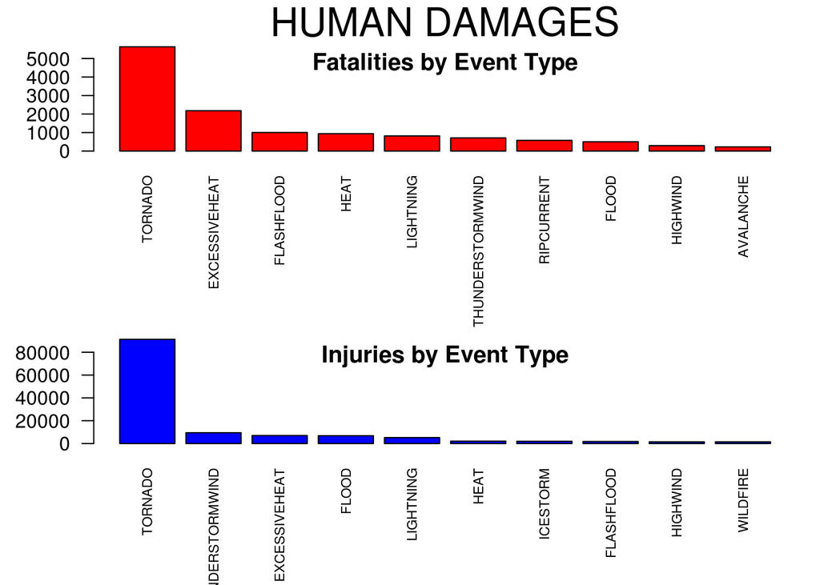

```r
    par(mfrow = c(2, 1), mar = c(6, 4, 2, 1))
    with(StormData.HumanDamages.fatal,
         barplot(FATALITIES, names.arg = EVTYPE, cex.names = 0.7, col = "red", las=2))
    title("Fatalities by Event Type", line = -1)
    mtext("HUMAN DAMAGES",side = 3, padj = 1, cex = 2, line = 1.5)
    with(StormData.HumanDamages.injur,
         barplot(INJURIES, names.arg = EVTYPE, cex.names = 0.7, col = "blue",las=2))
    title("Injuries by Event Type", line = -1)
```

### ECONOMY DAMAGES

First we select the columns that contain the economic damage data along with the Events column. In addition we select only the registers with value> 0.  
We must transform the alphanumeric data stored in the magnitude columns CROPDMGEXP and PROPDMGEXP into multipliers with which we can calculate data. The ‘magnitude’ function has been created to help us convert quantities. Next we have created a ‘Total’ column for each category of economic damage.

```r
    StormData.EcoDamages <- StormData[StormData$PROPDMG>0|StormData$CROPDMG>0,
                                      c("EVTYPE","PROPDMG","PROPDMGEXP","CROPDMG","CROPDMGEXP")]
    magnitude <- function(x) {
        if (x == "H")       {return(100)}
        else if (x == "K")  {return(1000)}
        else if (x == "M")  {return(1000000)}
        else if (x == "B")  {return(1000000000)}
        else return(1)
}
    # Make separate data columns for multipliers and totals
    StormData.EcoDamages$PROPDMG.MULT <- sapply(StormData.EcoDamages$PROPDMGEXP,
                    function(x) magnitude(x)) #Multiplier for Property Damages
    StormData.EcoDamages$TOTAL.PROPDMG <- with(StormData.EcoDamages, PROPDMG * PROPDMG.MULT) #Total Prop

    StormData.EcoDamages$CROPDMG.MULT <- sapply(StormData.EcoDamages$CROPDMGEXP,
                    function(x) magnitude(x)) #Multiplier for Crop Damages
    StormData.EcoDamages$TOTAL.CROPDMG <- with(StormData.EcoDamages, CROPDMG * CROPDMG.MULT) #Total Crop
```

Next we calculate the sums by Event type, as well as the total sum in the TOTAL column. Finally we rearrange the data by the column TOTAL downward, to keep the 10 most harmful events.

```r
    StormData.EcoDamages.Total <- na.omit(aggregate(cbind(TOTAL.PROPDMG, TOTAL.CROPDMG) ~ EVTYPE,
                    data = StormData.EcoDamages, FUN = sum)) #Computes agrregated sum

    StormData.EcoDamages.Total$TOTAL <- with(StormData.EcoDamages.Total, TOTAL.PROPDMG + TOTAL.CROPDMG)
    StormData.EcoDamages.Total <- StormData.EcoDamages.Total[order(StormData.EcoDamages.Total$TOTAL,
                    decreasing = TRUE),][1:10,]
```

The top ten events with the highest economic cost are:

```r
    print(StormData.EcoDamages.Total)
```

```
##               EVTYPE TOTAL.PROPDMG TOTAL.CROPDMG        TOTAL
## 55             FLOOD  144824274465    5679312050 150503586515
## 136        HURRICANE   84756180010    5515292800  90271472810
## 244          TORNADO   56937160779     414953270  57352114049
## 223       STORMSURGE   43323536000          5000  43323541000
## 84              HAIL   15732267543    3025954473  18758222016
## 46        FLASHFLOOD   16451375671    1436608150  17887983821
## 30           DROUGHT    1046106000   13972566000  15018672000
## 238 THUNDERSTORMWIND    9760543156    1224397988  10984941144
## 191       RIVERFLOOD    5118945500    5029459000  10148404500
## 145         ICESTORM    3944927860    5022113500   8967041360
```

We can see that the events with the worst economic consequences in absolute terms are the floods in the first place, followed by the hurricanes. However we can note that if we only consider the effects on crops, droughts would be the most damaging type of events.

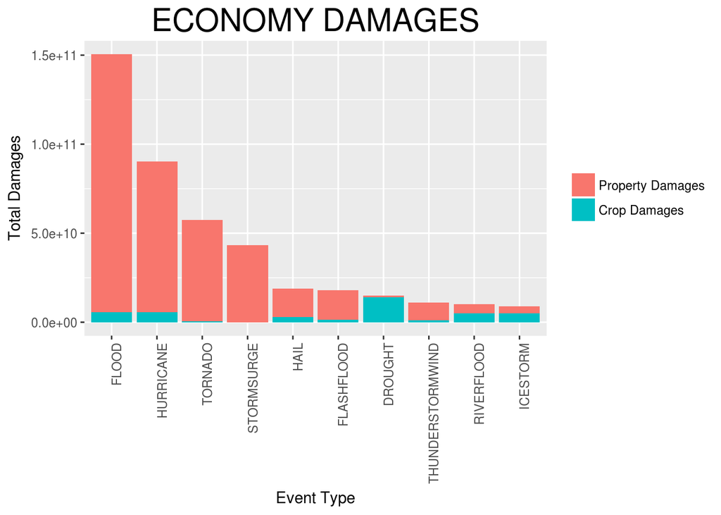

```r
    #Melt helps rearrange data to plot
    StormData.EcoDamages.Total.melted <- melt(StormData.EcoDamages.Total
                    [,c("EVTYPE","TOTAL.PROPDMG","TOTAL.CROPDMG")], id = c("EVTYPE"))
    p <- ggplot(StormData.EcoDamages.Total.melted) + geom_col(aes(x = reorder(EVTYPE, -value), y = value, fill = variable))
    p + labs(title = "ECONOMY DAMAGES", x = "Event Type", y = "Total Damages") + scale_color_manual() + theme(axis.text.x = element_text(angle = 90, hjust = 1), plot.title = element_text(hjust = 0.5, size=22)) + scale_fill_discrete(name = "", labels = c("Property Damages", "Crop Damages"))
```

As a final conclusion we can determine that the events with the worst consequences are those related to tornadoes, floods and droughts.